# Interpolation - Filling in the Blanks

Case Study 4

Created by Madeline Brown

Updated 08/20/2022

University of California, Merced  
School of Engineering  
Spatial Analysis and Modeling (ENGR 180)

Assignment deliverables in RED

## Case Study Scenario

NOTE: This assignment looks much longer than others: HOWEVER! It is much more “step by step” in its instruction style. Also, it has lots of screenshots taking up space- it will go surprisingly quick =)

Congrats! You scored summer employment with the Forest Service in Oregon on the Willamette National Forest! The Forest Service seasonally employs college students every year through their Pathways Program, placing them in relevant roles. With your experience in GIS, they hired you as an Office Automation Clerk, a fancy title for GISer.

As an Office Automation Clerk, you work for the District GIS Specialist and create maps and do geospatial analyses for ALL resource groups (aka departments), such as silviculture (tree specialists), hydrology, and wildlife.

The Wildlife Resource Group has a big project coming up, and needs you to brush up on your basic interpolation skills.

## Introduction

Please read all of the instructions/narrative carefully! You may feel compelled to skim to find which elements you have to satisfy to get full credit. *If you skim, you may miss key sentences and you may end up doing more work than necessary!* Also, if you have questions, give the lab handout a second reading. Your question is probably answered here!  
If text is in *italics*, it’s a tool or step within ArcGIS Pro.  
If text is underlined, it’s a file.

## Instructions

You will review interpolation basics to reinforce key ideas from text and lecture. You’ll learn the order of operations for making decisions prior to interpolating data, explore plots, and create an interpolated raster from vector (point) data.

### Part 1: Data Management

A Note on Data Management  
WARNING: Raster datasets are often large! Depending on how they were they were encoded, they may also compress well. You need to extract all .zip files in order for your files to be read by ArcGIS Pro, or Excel (or most any other program).  
Be mindful of your disk space, because some of these rasters expand to hundreds of megabytes when unzipped. You will need at least 1GB of free space for this lab. Have a plan for managing your data in your labs.

### Part 2: Interpolation Basics

*2.1 Defining Interpolation and Scenarios*  
Interpolation is defined as “*predicting values for cells in a raster from a limited number of sample data points*”[1].  
You could use interpolation to create a prediction for rainfall across the State of California, using data collected in rain gauges at each UC Campus (one campus rain gauge = 1 sample data point). California’s Air Resources Control Board can monitor air quality and make assessments using air quality data collected throughout the state along highway corridors.  
What other types of data could you interpolate?

### Part 3: Interpolating Elevation Surfaces: Triangular Irregular Networks (TINs)

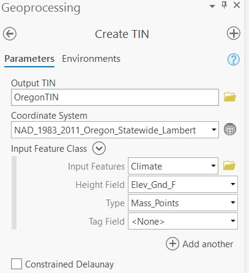

*Create TIN Geoprocessing Task*

1. Right click on your oregonTIN and access the *Symbology* pane.
2. Choose any number of classes LARGER than the default.
3. Click through the four icons at the top to visualize your TIN in different ways by checking and unchecking the *Draw* boxes

[figure not shown]

*Customize TIN symbology*

4. Choose the criteria to visualize your TIN with *Edges* on.
5. Ensure that your symbology color scheme appropriately communicates the variation in Oregon topography (can you see how it’s lower elevation on the coast, hits a ridge, then is higher elevation, but flatter, to the east)

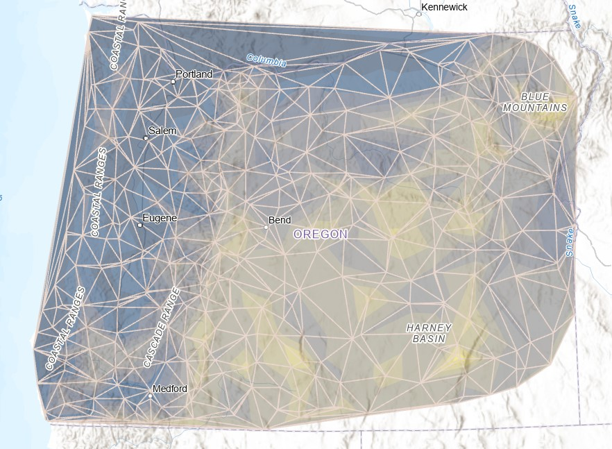

f. Submit a screenshot showing your TIN surface with *Edges* on.

We now have a general idea of the terrain of Oregon state.

From here, we will interpolate Climate data to see how climate varies over the TIN interpolated terrain, as well as if/how it varies by interpolation method.

### Part 4. Decision Making with Interpolation

*4.1 Order of Operations*: When we interpolate data, we must work through an order of operations.

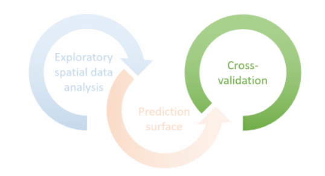

*Visual Summary courtesy of Esri*

### Part 5. Plot Exploration

*5.1 Verify Assumption Visually: Normal Distribution*  
To run statistical analyses and successfully (and correctly) interpolate data, we need to make sure out data is “normally distributed”

Next: Create a Histogram and Q-Q Plot Visual Interpretation

1. In the *Contents* pane, right-click Climate, point to *Create Chart*, and then choose *Histogram*. A histogram chart window and the *Chart Properties* pane appear.
2. Next, specify the variable that represents the measurements of the phenomenon of interest.
3. In the *Chart Properties - Climate* pane, for *Number*, choose *Mean Aug Temp*.
4. Next, you will visually interpret the chart to determine whether the data is normally distributed.
5. Check the *Show Normal Distribution* box to add a normal distribution reference line to the chart.
6. Check the *Median* box to add a line representing the median value to the chart.  
   Submit a screenshot of the chart created for Mean Aug Temp with the mean, median, and normal distribution reference line. Based on a visual interpretation of the chart, are the values for Mean Aug Temp normally distributed?

You have completed the visual verification that the data appear to be normally distributed, but we need to be able to prove it with numbers as well.  
*5.2 Verify Assumption Numerically: Normal Distribution*  
Now you will review the chart statistics to determine whether the data is normally distributed.  
j. In the *Chart Properties - Climate* pane, review the mean, median, skewness, and kurtosis statistics.  
k. Histogram chart properties statistics: Based on these statistics, is the data normally distributed?  
Submit a screenshot of you statistical/numerical results. Explain in written format if the data are normally distributed based on your statistical/numerical results.  
Close your *Chart Properties* and the *Distribution Chart* created for mean august temps  
*Q-Q Plots*  
a. In the *Contents* pane, right-click Climate, point to *Create Chart*, and choose *QQ Plot*. A *QQ plot* chart window and the *Chart Properties* pane will appear. First, you will specify the variable that represents the measurements of the phenomenon of interest.  
b. In the *Chart Properties - Climate* pane, for *Compare The Distribution Of*, choose Mean Aug Temp.

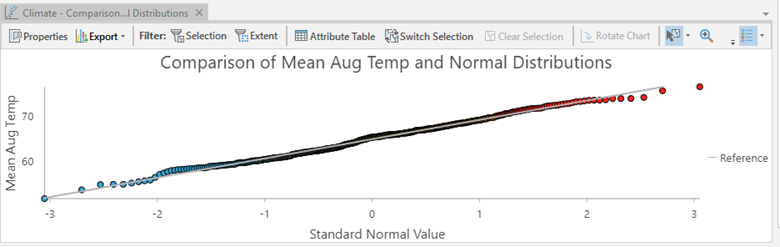

*Chart*

### Part 6. Interpolation Methods

**How to Choose a Method of Interpolation**

Phenomena can be measured in various ways depending on your analysis goal.

The data type of a measured phenomenon determines which geostatistical interpolation methods apply to the analysis. However, the cross-validation metrics and graphs should be evaluated to ensure that the prediction surface is valid.

2D Surfaces: x coordinate, y coordinate, value for thing being measured

3D Surfaces: x coordinate, y coordinate, z coordinate (aka elevation)  
and value for thing being measured

Polygon Surfaces: reaggregate (up or downscale) polygons to fill in missing data

Now that we know what three datatypes we can interpolate with, we can look at different types of interpolating to do for each datatype.

Is our climate data 2D, 3D, or Polygon? When we looked at the attribute table, we can see there is an Elev_Gnd_F (ground elevation in feet) and Elev_Gnd_m (ground elevation in meters).

Submit a screenshot showing the spatial reference for the Climate layer and highlight/circle the units.

### Part 7. Interpolating Practice: Kriging

Pronounced Kreeeging…  
Kriging looks at points within a specific distance range to calculate missing values. It is a *geostatistical* approach to interpolation, also called a *stochastic* method. [2]

Search for the *Geoprocessing* tool *Empirical Bayesian Kriging* and open it.  
a. Set your input features to Climate (your data layer)  
b. Set your Z value field to Mean Aug Temp  
c. Wait, isn’t Z normally representative of elevation? Hover over the blue info icon and read the description. It says…” Field that holds a height or magnitude value for each point… we’re analyzing August Mean Temp, not elevation, so that’s why we’re inputting Mean August Temperatures.  
d. Name your output raster ClimateKriging  
e. Accept all other defaults.  
Click the dropdown for *Output Parameters*: See that we are creating a prediction surface? Remember that was the middle of 3 steps within the interpolation workflow.  
f. *Run* the Tool.

### Part 8. Interpolating Practice: Inverse Distance Weighting (IDW)

With Inverse Distance Weighting, the “strength” of influence one point has on another decreases the farther away it is. Unlike Kriging, IDW looks at ALL the points and assigns weights. It is a *deterministic* method of interpolation [3]

From QGIS: “In the IDW interpolation method, the sample points are weighted during interpolation such that the influence of one point relative to another declines with distance from the unknown point you want to create.”

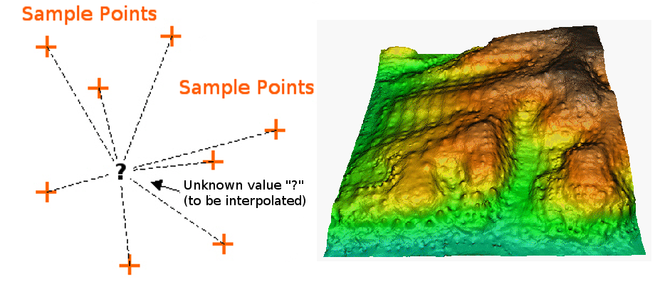

*Inverse Distance Weighting*

In your ArcGIS Pro project…

1. Access the IDW (Geostatistical Analyst Tool) geoprocessing tool
2. Set your input features to Climate (your data layer)
3. Set your Z value field to Mean Aug Temp
4. Name your Output geostatistical laer ClimateIDW
5. Accept the remaining defaults and *Run*

### Part 9: Compare and Contrast Methods

Take screenshots of both your ClimateKriging and ClimateIDW layers.  
Paste the images side by side in a document for submission.

Respond to the following four questions:  
1 . Explain why there are differences in the two climate layers you interpolated. How/why does the method influence the visual result? Be specific to this dataset.  
2. Desribe how the two climate layers correspond to the interpolated Elevation TIN we made, particularly change in temperature correlating/corresponding to elevatio.  
3. Do ClimateKriging and ClimateIDW communitcate the same message to your map reader? Explain your reasoning.  
4. Can we use TIN interpolation on the climate data, in addition to kriging and IDW? Why or why not?

You may use additional resources to answer this question, just be sure to cite them!

## Submission

At the end of this lab, you should have generated the following:  
-2.2: Written response - What types of data are in the attribute table (based off the column headers)? How many sites are there (what is the number of assets in the table/number of rows)?  
-3.2: Screenshot of TIN surface with Edges on  
-5.1: Submit a screenshot of the chart created for Mean Aug Temp with the mean, median, and normal distribution reference line. Based on a visual interpretation of the chart, are the values for Mean Aug Temp normally distributed?  
-9: Four written responses

## References

[1]https://pro.arcgis.com/en/pro-app/2.8/tool-reference/spatial-analyst/comparing-interpolation-methods.htm

[2] https://desktop.arcgis.com/en/arcmap/10.3/tools/3d-analyst-toolbox/how-kriging-works.htm

[3] https://pro.arcgis.com/en/pro-app/latest/help/analysis/geostatistical-analyst/how-inverse-distance-weighted-interpolation-works.htm